# **TRABALHO FINAL - ETAPA 3 - ANÁLISE CLUSTER**

**Integrantes do Grupo:**

- Alexandre Marcelo Marques Filho
- João Victor Tozoni
- Pedro Humberto Bitencourt Nascimento

**Tema:** Percepção de Carreira e Ambiente de Trabalho

**Disciplina:** Análise de Dados IV

**Professor:** José Eduardo

## 1. Introdução e Objetivos

### 1.1 Contexto

A área de dados no Brasil vem crescendo exponencialmente nos últimos anos, com a criação de novas profissões, ferramentas e metodologias. Entender como os profissionais dessa área se organizam em grupos com características similares é fundamental para:

- **Instituições de Ensino:** Desenvolver currículos alinhados com o mercado
- **Empresas:** Estruturar times de dados e planos de carreira
- **Profissionais:** Identificar oportunidades de desenvolvimento
- **Formuladores de Políticas:** Compreender dinâmicas do mercado

### 1.2 Objetivos

Este estudo aplica **Análise de Agrupamentos (Cluster Analysis)** para identificar segmentos homogêneos de profissionais da área de dados no Brasil, utilizando dados do State of Data Brazil 2024.

### 1.3 Questões de Pesquisa

1. Quantos perfis distintos de profissionais de dados existem no mercado brasileiro?
2. Quais características melhor diferenciam esses grupos?
3. Como os grupos se diferenciam em satisfação profissional e remuneração?
4. Quais são as tecnologias predominantes em cada cluster?

### 1.4 Metodologia

**Fonte dos Dados**

Os dados utilizados foram extraídos da 5ª edição da pesquisa "State of Data Brazil", conduzida pela Data Hackers em parceria com a Bain & Company. A coleta ocorreu entre 14 de outubro e 18 de dezembro de 2024, com a participação de 5.217 profissionais brasileiros da área de dados.

> Fonte do Dataset: https://www.kaggle.com/datasets/datahackers/state-of-data-brazil-20242025?resource=download

```python
# Importação de Bibliotecas
import pandas as pd
import numpy as np
import matplotlib.pyplot as plt
import seaborn as sns
import plotly.express as px
import plotly.graph_objects as go
from plotly.subplots import make_subplots

from scipy import stats
from scipy.cluster.hierarchy import dendrogram, linkage, fcluster
from scipy.spatial.distance import pdist, squareform

from sklearn.preprocessing import StandardScaler, LabelEncoder
from sklearn.cluster import KMeans, AgglomerativeClustering
from sklearn.metrics import silhouette_score, davies_bouldin_score, calinski_harabasz_score
from sklearn.decomposition import PCA

import warnings
warnings.filterwarnings('ignore')

# Configurações de visualização
plt.style.use('seaborn-v0_8-darkgrid')
sns.set_palette("husl")

pd.set_option('display.max_columns', None)
pd.set_option('display.max_rows', 100)
pd.set_option('display.float_format', '{:.3f}'.format)

print("Bibliotecas importadas com sucesso!")
```

```
Bibliotecas importadas com sucesso!
```

## 2. Fundamentação Teórica

### 2.1 Análise de Cluster

A **Análise de Agrupamentos** é uma técnica de aprendizado não supervisionado que agrupa objetos com base nas características que possuem, considerando:

- **Homogeneidade Interna:** Objetos dentro de um cluster devem ser similares entre si
- **Heterogeneidade Externa:** Clusters diferentes devem ser distintos entre si

### 2.2 Medidas de Similaridade

Utilizaremos a **Distância Euclidiana Quadrada**:

$$d_{ij}^2 = \sum_{k=1}^{p} (x_{ik} - x_{jk})^2$$

Onde:

- $x_{ik}$ = valor da variável $k$ para o objeto $i$
- $x_{jk}$ = valor da variável $k$ para o objeto $j$
- $p$ = número de variáveis

### 2.3 Métodos de Agrupamento

#### 2.3.1 Método Hierárquico (Ward)

O método de Ward minimiza a variância dentro dos clusters, unindo em cada passo os clusters que causam menor aumento na soma total de quadrados dentro dos grupos.

#### 2.3.2 Método Não-Hierárquico (K-means)

Particiona os dados em K clusters pré-definidos, minimizando a variância intra-cluster e maximizando a variância inter-cluster.

### 2.4 Padronização (Z-score)

Para evitar que variáveis com escalas diferentes dominem a análise:

$$Z = \frac{x - \bar{x}}{s}$$

Onde:

- $x$ = valor original
- $\bar{x}$ = média
- $s$ = desvio padrão

## 3. Preparação dos Dados

### Propósito da Análise

**Carregar e preparar o dataset** verificando suas dimensões, estrutura e qualidade, garantindo que os dados estejam prontos para análise.

```python
print("="*80)
print(" "*25 + "CARREGAMENTO DOS DADOS")
print("="*80)

# Carregar dados
df = pd.read_csv('Final Dataset - State of Data 2024 - Kaggle - df_survey_2024.csv')

print(f"\n Dimensões do dataset: {df.shape}")
print(f" Linhas: {df.shape[0]:,}")
print(f" Colunas: {df.shape[1]:,}")
print(f"\n Dataset carregado com sucesso!")
```

```
================================================================================
                         CARREGAMENTO DOS DADOS
================================================================================

 Dimensões do dataset: (5217, 403)
 Linhas: 5,217
 Colunas: 403

 Dataset carregado com sucesso!
```

### Propósito da Análise

**Filtrar profissionais ativos na área** para garantir que a análise reflita apenas o perfil de quem está efetivamente trabalhando com dados atualmente.

```python
print("\n FILTRANDO DADOS...")
print("="*80)

# Filtrar apenas profissionais que trabalham atualmente na área
df_trabalho = df[
    df['2.a_situação_de_trabalho'].isin([
        'Empregado (CLT)',
        'Empreendedor ou Empregado (CNPJ)',
        'Estagiário'
    ])
].copy()

df_trabalho = df_trabalho[df_trabalho['4.a.1_atuacao_em_dados'].notna()].copy()

print(f" Profissionais ativos filtrados: {df_trabalho.shape[0]:,} registros")
print(f" Percentual mantido: {df_trabalho.shape[0]/df.shape[0]*100:.1f}%")
```

```
 FILTRANDO DADOS...
================================================================================
 Profissionais ativos filtrados: 4,463 registros
 Percentual mantido: 85.5%
```

### Propósito da Análise

**Selecionar variáveis relevantes** para segmentação, incluindo características demográficas, profissionais, técnicas e de satisfação que possam diferenciar perfis.

```python
# Selecionar variáveis para análise de cluster
variaveis_cluster = [
    # Demográficas
    '1.a_idade',
    '1.b_genero',
    '1.i.2_regiao_onde_mora',
    '1.l_nivel_de_ensino',

    # Profissionais
    '2.f_cargo_atual',
    '2.g_nivel',
    '2.h_faixa_salarial',
    '2.i_tempo_de_experiencia_em_dados',
    '2.c_numero_de_funcionarios',
    '2.b_setor',

    # Técnicas
    '4.a.1_atuacao_em_dados',
    '4.e_linguagem_mais_usada',
    '4.i_cloud_preferida',
    '4.k_ferramenta_de_bi_preferida',

    # Satisfação
    '2.k_satisfeito_atualmente',
    '2.r_modelo_de_trabalho_atual',
]

df_cluster = df_trabalho[variaveis_cluster].copy()

print(f" Dataset para cluster: {df_cluster.shape}")
print(f" Variáveis selecionadas: {len(variaveis_cluster)}")
print(f"\n Categorias de variáveis:")
print(f"   • Demográficas: 4")
print(f"   • Profissionais: 6")
print(f"   • Técnicas: 4")
print(f"   • Satisfação: 2")
```

```
 Dataset para cluster: (4463, 16)
 Variáveis selecionadas: 16

 Categorias de variáveis:
   • Demográficas: 4
   • Profissionais: 6
   • Técnicas: 4
   • Satisfação: 2
```

## 4. Análise Exploratória

### Propósito da Análise

**Identificar valores ausentes** nas variáveis selecionadas para tomar decisões informadas sobre tratamento de dados faltantes.

```python
print("="*80)
print(" "*25 + "ANÁLISE EXPLORATÓRIA")
print("="*80)

# Análise de valores ausentes
missing = pd.DataFrame({
    'Variável': df_cluster.columns,
    'Missing': df_cluster.isnull().sum(),
    'Missing (%)': (df_cluster.isnull().sum() / len(df_cluster) * 100).round(2)
}).sort_values('Missing (%)', ascending=False)

print("\n Valores Ausentes:")
print(missing.to_string(index=False))
```

```
================================================================================
                         ANÁLISE EXPLORATÓRIA
================================================================================

 Valores Ausentes:
                         Variável  Missing  Missing (%)
   4.k_ferramenta_de_bi_preferida     1434       32.130
         4.e_linguagem_mais_usada     1299       29.110
              4.i_cloud_preferida     1143       25.610
                        2.g_nivel      955       21.400
                  2.f_cargo_atual      955       21.400
           1.i.2_regiao_onde_mora       43        0.960
              1.l_nivel_de_ensino        0        0.000
                        1.a_idade        0        0.000
2.i_tempo_de_experiencia_em_dados        0        0.000
               2.h_faixa_salarial        0        0.000
                       1.b_genero        0        0.000
       2.c_numero_de_funcionarios        0        0.000
           4.a.1_atuacao_em_dados        0        0.000
                        2.b_setor        0        0.000
        2.k_satisfeito_atualmente        0        0.000
     2.r_modelo_de_trabalho_atual        0        0.000
```

### Propósito da Análise

**Remover variáveis com alto percentual de missing** (>30%) e registros incompletos para garantir qualidade e consistência dos dados.

```python
# Remover variáveis com muitos missing e linhas com missing
threshold_missing = 30
vars_excluir = missing[missing['Missing (%)'] > threshold_missing]['Variável'].tolist()

if vars_excluir:
    print(f" Removendo variáveis com >{threshold_missing}% de missing:")
    for var in vars_excluir:
        print(f"   - {var}")
    df_cluster = df_cluster.drop(columns=vars_excluir)
else:
    print(" Nenhuma variável excluída por missing")

df_cluster_clean = df_cluster.dropna()

print(f"\n Dataset limpo: {df_cluster_clean.shape}")
print(f" Registros mantidos: {len(df_cluster_clean):,}")
print(f" Percentual mantido: {len(df_cluster_clean)/len(df_cluster)*100:.1f}%")
```

```
 Removendo variáveis com >30% de missing:
   - 4.k_ferramenta_de_bi_preferida

 Dataset limpo: (3134, 15)
 Registros mantidos: 3,134
 Percentual mantido: 70.2%
```

### Propósito da Análise

**Transformar variáveis categóricas em numéricas** através de mapeamentos ordinais (para variáveis com ordem natural) e label encoding (para variáveis nominais).

```python
print(" CODIFICANDO VARIÁVEIS CATEGÓRICAS...")
print("="*80)

df_encoded = df_cluster_clean.copy()

# Mapeamentos ordinais
mapping_nivel = {
    'Júnior': 1, 'Pleno': 2, 'Sênior': 3,
    'Especialista': 4, 'C-Level/Diretor': 5
}

mapping_salario = {
    'Menos de R$ 1.000/mês': 1,
    'de R$ 1.001/mês a R$ 2.000/mês': 2,
    'de R$ 2.001/mês a R$ 3.000/mês': 3,
    'de R$ 3.001/mês a R$ 4.000/mês': 4,
    'de R$ 4.001/mês a R$ 6.000/mês': 5,
    'de R$ 6.001/mês a R$ 8.000/mês': 6,
    'de R$ 8.001/mês a R$ 12.000/mês': 7,
    'de R$ 12.001/mês a R$ 16.000/mês': 8,
    'de R$ 16.001/mês a R$ 20.000/mês': 9,
    'de R$ 20.001/mês a R$ 25.000/mês': 10,
    'de R$ 25.001/mês a R$ 30.000/mês': 11,
    'de R$ 30.001/mês a R$ 40.000/mês': 12,
    'Acima de R$ 40.001/mês': 13
}

mapping_experiencia = {
    'Não tenho experiência na área de dados': 0,
    'Menos de 1 ano': 1,
    'de 1 a 2 anos': 2,
    'de 3 a 4 anos': 3,
    'de 5 a 6 anos': 4,
    'de 7 a 10 anos': 5,
    'Mais de 10 anos': 6
}

# Aplicar mapeamentos
if '2.g_nivel' in df_encoded.columns:
    df_encoded['2.g_nivel'] = df_encoded['2.g_nivel'].map(mapping_nivel)

if '2.h_faixa_salarial' in df_encoded.columns:
    df_encoded['2.h_faixa_salarial'] = df_encoded['2.h_faixa_salarial'].map(mapping_salario)

if '2.i_tempo_de_experiencia_em_dados' in df_encoded.columns:
    df_encoded['2.i_tempo_de_experiencia_em_dados'] = df_encoded['2.i_tempo_de_experiencia_em_dados'].map(mapping_experiencia)

if '2.k_satisfeito_atualmente' in df_encoded.columns:
    # Convertendo para string e depois para maiúsculas para robustez no mapeamento
    df_encoded['2.k_satisfeito_atualmente'] = df_encoded['2.k_satisfeito_atualmente'].astype(str).str.upper().map({'FALSE': 0, 'TRUE': 1})

    # Verificar se a coluna ficou totalmente NaN após o mapeamento usando .count() == 0
    if df_encoded['2.k_satisfeito_atualmente'].count() == 0:
        print("   • A coluna '2.k_satisfeito_atualmente' ficou totalmente NaN após o mapeamento e será removida.")
        df_encoded = df_encoded.drop(columns=['2.k_satisfeito_atualmente'])
    else:
        print("   • Coluna '2.k_satisfeito_atualmente' tem valores válidos.")

# Identificar e remover quaisquer colunas que tenham ficado totalmente NaN após o encoding (reforço)
cols_to_drop_after_encoding = df_encoded.columns[df_encoded.isnull().all()].tolist()
if cols_to_drop_after_encoding:
    print(f"   • Removendo colunas que ficaram totalmente NaN após encoding (reforço): {cols_to_drop_after_encoding}")
    df_encoded = df_encoded.drop(columns=cols_to_drop_after_encoding)
else:
    print("   • Nenhuma coluna foi removida por estar totalmente NaN após encoding (reforço).")

# Label encoding para outras variáveis
le = LabelEncoder()
for col in df_encoded.columns:
    if df_encoded[col].dtype == 'object':
        df_encoded[col] = le.fit_transform(df_encoded[col].astype(str))

print(" Variáveis codificadas:")
print(f"   • Ordinais: Nível, Salário, Experiência, Satisfação")
print(f"   • Nominais: {sum(df_encoded.dtypes != 'object')} variáveis")
```

[output not shown]

### Propósito da Análise

**Examinar estatísticas descritivas** das variáveis numéricas para entender distribuições, centralidade e dispersão dos dados.

```python
print("\n ESTATÍSTICAS DESCRITIVAS:")
print("="*80)
df_encoded.describe().T.round(2)
```

```
 ESTATÍSTICAS DESCRITIVAS:
================================================================================
```

|  | count | mean | std | min | 25% | 50% | 75% | max |
| --- | --- | --- | --- | --- | --- | --- | --- | --- |
| 1.a_idade | 3134.000 | 30.890 | 6.490 | 18.000 | 27.000 | 30.000 | 34.000 | 66.000 |
| 1.b_genero | 3134.000 | 0.760 | 0.450 | 0.000 | 1.000 | 1.000 | 1.000 | 3.000 |
| 1.i.2_regiao_onde_mora | 3134.000 | 2.850 | 1.060 | 0.000 | 3.000 | 3.000 | 3.000 | 4.000 |
| 1.l_nivel_de_ensino | 3134.000 | 3.340 | 2.050 | 0.000 | 2.000 | 2.000 | 6.000 | 6.000 |
| 2.f_cargo_atual | 3134.000 | 4.500 | 3.610 | 0.000 | 1.000 | 4.000 | 8.000 | 14.000 |
| 2.g_nivel | 3134.000 | 2.210 | 0.760 | 1.000 | 2.000 | 2.000 | 3.000 | 3.000 |
| 2.h_faixa_salarial | 3134.000 | 6.370 | 1.900 | 1.000 | 5.000 | 7.000 | 8.000 | 13.000 |
| 2.i_tempo_de_experiencia_em_dados | 3134.000 | 3.140 | 1.320 | 0.000 | 2.000 | 3.000 | 4.000 | 6.000 |
| 2.c_numero_de_funcionarios | 3134.000 | 1.760 | 2.080 | 0.000 | 0.000 | 0.000 | 3.000 | 7.000 |
| 2.b_setor | 3134.000 | 10.710 | 6.410 | 0.000 | 4.000 | 10.000 | 16.000 | 20.000 |
| 4.a.1_atuacao_em_dados | 3134.000 | 0.910 | 0.970 | 0.000 | 0.000 | 1.000 | 2.000 | 3.000 |
| 4.e_linguagem_mais_usada | 3134.000 | 9.600 | 1.710 | 0.000 | 8.000 | 11.000 | 11.000 | 13.000 |
| 4.i_cloud_preferida | 3134.000 | 3.060 | 2.690 | 0.000 | 0.000 | 5.000 | 6.000 | 10.000 |
| 2.k_satisfeito_atualmente | 3134.000 | 0.700 | 0.460 | 0.000 | 0.000 | 1.000 | 1.000 | 1.000 |
| 2.r_modelo_de_trabalho_atual | 3134.000 | 1.420 | 0.940 | 0.000 | 1.000 | 1.000 | 2.000 | 3.000 |

## 5. Padronização das Variáveis

### Propósito da Análise

**Padronizar variáveis usando Z-score** para garantir que todas tenham mesma escala (média=0, desvio=1), evitando que variáveis com maior magnitude dominem a análise.

```python
print("="*80)
print(" "*25 + "PADRONIZAÇÃO (Z-SCORE)")
print("="*80)

scaler = StandardScaler()
df_scaled = pd.DataFrame(
    scaler.fit_transform(df_encoded),
    columns=df_encoded.columns,
    index=df_encoded.index
)

print(" Dados padronizados!")
print("\n Verificação (média ≈ 0, desvio ≈ 1):")
verificacao = pd.DataFrame({
    'Variável': df_scaled.columns,
    'Média': df_scaled.mean().round(6),
    'Desvio Padrão': df_scaled.std().round(6)
})
verificacao.head(10)
```

```
================================================================================
                         PADRONIZAÇÃO (Z-SCORE)
================================================================================
 Dados padronizados!

 Verificação (média ≈ 0, desvio ≈ 1):
```

|  | Variável | Média | Desvio Padrão |
| --- | --- | --- | --- |
| 1.a_idade | 1.a_idade | -0.000 | 1.000 |
| 1.b_genero | 1.b_genero | 0.000 | 1.000 |
| 1.i.2_regiao_onde_mora | 1.i.2_regiao_onde_mora | 0.000 | 1.000 |
| 1.l_nivel_de_ensino | 1.l_nivel_de_ensino | -0.000 | 1.000 |
| 2.f_cargo_atual | 2.f_cargo_atual | -0.000 | 1.000 |
| 2.g_nivel | 2.g_nivel | 0.000 | 1.000 |
| 2.h_faixa_salarial | 2.h_faixa_salarial | -0.000 | 1.000 |
| 2.i_tempo_de_experiencia_em_dados | 2.i_tempo_de_experiencia_em_dados | -0.000 | 1.000 |
| 2.c_numero_de_funcionarios | 2.c_numero_de_funcionarios | 0.000 | 1.000 |
| 2.b_setor | 2.b_setor | 0.000 | 1.000 |

## 6. Detecção de Outliers

### Propósito da Análise

**Calcular distância de Mahalanobis** para identificar observações atípicas multivariadas que possam distorcer os clusters, considerando correlações entre variáveis.

```python
print("="*80)
print(" "*25 + "DETECÇÃO DE OUTLIERS")
print("="*80)

def mahalanobis_distance(x, data):
    """Calcula distância de Mahalanobis"""
    x_minus_mu = x - np.mean(data, axis=0)
    cov = np.cov(data.T)
    try:
        # Adicionado um pequeno valor à diagonal para evitar matriz singular, se necessário
        # Mas o principal é garantir que 'data' não seja de variância zero ou colinear
        inv_covmat = np.linalg.inv(cov + np.eye(cov.shape[0]) * 1e-6)
        left_term = np.dot(x_minus_mu, inv_covmat)
        mahal = np.dot(left_term, x_minus_mu.T)
        return mahal
    except np.linalg.LinAlgError: # Catch specific error for singular matrix
        return None
    except Exception as e: # Catch other potential errors
        # print(f"Erro no cálculo da Mahalanobis para uma linha: {e}") # For debugging
        return None

# Remover colunas com variância zero (constantes) de df_scaled antes de calcular Mahalanobis
zero_var_cols = df_scaled.columns[df_scaled.std() == 0].tolist()
if zero_var_cols:
    print(f"   • Removendo colunas com variância zero para cálculo de Mahalanobis: {zero_var_cols}")
    df_scaled = df_scaled.drop(columns=zero_var_cols)

# IMPORTANTE: Verificar se df_scaled ficou vazio após remover colunas
if df_scaled.empty:
    print("\nAVISO: DataFrame 'df_scaled' está vazio após remover colunas de variância zero. Não é possível calcular a Distância de Mahalanobis.")
    # Criar um df_final vazio com as colunas esperadas para evitar erros downstream
    df_final = pd.DataFrame(columns=df_encoded.columns.drop(zero_var_cols, errors='ignore'))
    print(f"\n Dataset final para clustering: {df_final.shape}")
else:
    print(" Calculando D² de Mahalanobis...")
    # Preparar a matriz de dados para o cálculo da covariância UMA VEZ
    # Isso garante que 'data' seja consistente e não contenha 'D2_Mahalanobis' durante o apply
    data_for_cov = df_scaled.values

    d2_mahalanobis_results = df_scaled.apply(
        lambda row: mahalanobis_distance(row.values, data_for_cov),
        axis=1
    )
    # Atribuir os resultados como uma Series para garantir compatibilidade de comprimento
    df_scaled['D2_Mahalanobis'] = d2_mahalanobis_results

    df_scaled = df_scaled[df_scaled['D2_Mahalanobis'].notna()]

    print(f"\n D² Estatísticas:")
    # Verificar se ainda há dados válidos após remover NaNs
    if not df_scaled.empty and 'D2_Mahalanobis' in df_scaled.columns:
        print(df_scaled['D2_Mahalanobis'].describe().round(2))
    else:
        print("Nenhuma Distância de Mahalanobis válida foi calculada.")

    if not df_scaled.empty and 'D2_Mahalanobis' in df_scaled.columns:
        threshold = np.percentile(df_scaled['D2_Mahalanobis'], 95)
        outliers = df_scaled[df_scaled['D2_Mahalanobis'] > threshold]

        print(f"\n Outliers identificados (P95): {len(outliers)} ({len(outliers)/len(df_scaled)*100:.1f}%)")
        print("Decisão: Manter outliers (podem representar perfis profissionais legítimos)")

        df_final = df_scaled.drop('D2_Mahalanobis', axis=1)
    else:
        print("\nNenhum outlier identificado, pois não há dados válidos de Distância de Mahalanobis.")
        df_final = pd.DataFrame() # df_final vazio se não houver D2 válido
    print(f"\n Dataset final para clustering: {df_final.shape}")
```

```
================================================================================
                         DETECÇÃO DE OUTLIERS
================================================================================
 Calculando D² de Mahalanobis...

 D² Estatísticas:
count   3134.000
mean      15.000
std        6.210
min        3.900
25%       10.940
50%       13.650
75%       17.390
max       60.610
Name: D2_Mahalanobis, dtype: float64

 Outliers identificados (P95): 157 (5.0%)
Decisão: Manter outliers (podem representar perfis profissionais legítimos)

 Dataset final para clustering: (3134, 15)
```

## 7. Análise Hierárquica de Cluster

### Propósito da Análise

**Aplicar método hierárquico de Ward** para determinar o número ideal de clusters através do dendrograma e esquema de aglomeração.

```python
print("="*80)
print(" "*20 + "ANÁLISE HIERÁRQUICA DE CLUSTER")
print("="*80)

# Amostragem para análise hierárquica
np.random.seed(42)
sample_size = min(500, len(df_final))
df_sample = df_final.sample(n=sample_size, random_state=42)

print(f" Amostra para análise hierárquica: {df_sample.shape}")
print(f"   Utilizando {sample_size} observações para otimizar processamento")

# Calcular linkage (Ward)
print("\n Calculando linkage (Método de Ward)...")
linkage_matrix = linkage(df_sample, method='ward', metric='euclidean')
print("Linkage calculado!")
```

```
================================================================================
                    ANÁLISE HIERÁRQUICA DE CLUSTER
================================================================================
 Amostra para análise hierárquica: (500, 15)
   Utilizando 500 observações para otimizar processamento

 Calculando linkage (Método de Ward)...
Linkage calculado!
```

### Propósito da Análise

**Analisar esquema de aglomeração** para identificar saltos significativos nas distâncias de fusão, indicando número natural de clusters.

```python
# Análise do esquema de aglomeração
last_steps = 20
last_merges = linkage_matrix[-last_steps:, 2]

agglom_schedule = pd.DataFrame({
    'Estágio': range(len(linkage_matrix) - last_steps + 1, len(linkage_matrix) + 1),
    'N_Clusters': range(last_steps, 0, -1),
    'Distância': last_merges,
    'Incremento': np.diff(np.concatenate([[0], last_merges]))
})

agglom_schedule['Incremento_%'] = (
    agglom_schedule['Incremento'] / agglom_schedule['Distância'].shift(1) * 100
).round(2)

print("ESQUEMA DE AGLOMERAÇÃO (Últimos Passos):")
print("="*80)
print(agglom_schedule)

# Identificar saltos significativos
threshold_pct = 15
saltos = agglom_schedule[agglom_schedule['Incremento_%'] > threshold_pct]

print(f"\n Saltos Significativos (>{threshold_pct}%):")
if len(saltos) > 0:
    print(saltos[['N_Clusters', 'Incremento_%']])
    n_clusters_sugerido = saltos.iloc[0]['N_Clusters']
    print(f"\n Sugestão inicial baseada em saltos: {int(n_clusters_sugerido)} clusters")
else:
    n_clusters_sugerido = 4
    print(f"\n Sugestão padrão: {n_clusters_sugerido} clusters")

clusters_testar = [3, 4, 5, 6]
print(f"\n Testaremos K = {clusters_testar} na análise K-means")
```

```
ESQUEMA DE AGLOMERAÇÃO (Últimos Passos):
================================================================================
    Estágio  N_Clusters  Distância  Incremento  Incremento_%
0       480          20     10.913      10.913           NaN
1       481          19     10.914       0.000         0.000
2       482          18     11.712       0.798         7.310
3       483          17     11.879       0.167         1.430
4       484          16     11.917       0.039         0.330
5       485          15     11.964       0.047         0.390
6       486          14     12.133       0.169         1.410
7       487          13     12.868       0.735         6.060
8       488          12     13.504       0.635         4.940
9       489          11     14.742       1.238         9.170
10      490          10     15.372       0.630         4.270
11      491           9     16.757       1.385         9.010
12      492           8     16.907       0.150         0.890
13      493           7     18.068       1.162         6.870
14      494           6     18.661       0.593         3.280
15      495           5     19.686       1.025         5.490
16      496           4     21.664       1.977        10.040
17      497           3     22.940       1.276         5.890
18      498           2     28.160       5.220        22.760
19      499           1     38.300      10.140        36.010

 Saltos Significativos (>15%):
    N_Clusters  Incremento_%
18           2        22.760
19           1        36.010

 Sugestão inicial baseada em saltos: 2 clusters

 Testaremos K = [3, 4, 5, 6] na análise K-means
```

### Visualização do Dendrograma

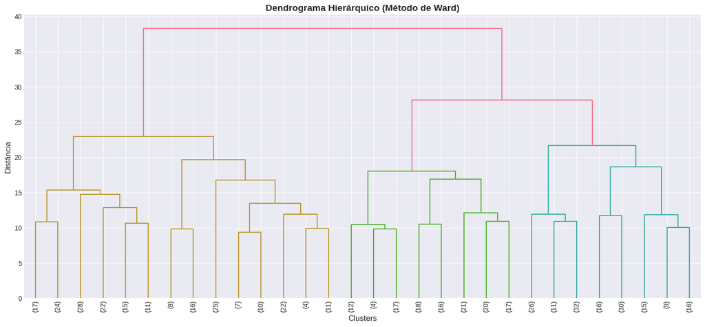

```python
plt.figure(figsize=(15, 7))
dendrogram(linkage_matrix, truncate_mode='lastp', p=30, leaf_rotation=90)
plt.title('Dendrograma Hierárquico (Método de Ward)', fontsize=14, fontweight='bold')
plt.xlabel('Clusters', fontsize=12)
plt.ylabel('Distância', fontsize=12)
plt.tight_layout()
plt.show()
```

## 8. Análise Não-Hierárquica (K-means)

### Propósito da Análise

**Testar diferentes valores de K** utilizando múltiplas métricas de validação (Silhouette, Davies-Bouldin, Calinski-Harabasz) para determinar número ótimo de clusters.

```python
print("="*80)
print(" "*20 + "ANÁLISE NÃO-HIERÁRQUICA (K-MEANS)")
print("="*80)

# Método do Cotovelo + Métricas de Validação
print(" Calculando métricas para diferentes valores de K...")
print("="*80)

K_range = range(2, 11)
inertias = []
silhouette_scores = []
davies_bouldin_scores = []
calinski_harabasz_scores = []

for k in K_range:
    print(f"   K = {k}...", end=' ')
    kmeans = KMeans(n_clusters=k, init='k-means++', n_init=50, random_state=42, max_iter=300)
    kmeans.fit(df_final)

    inertias.append(kmeans.inertia_)
    silhouette_scores.append(silhouette_score(df_final, kmeans.labels_))
    davies_bouldin_scores.append(davies_bouldin_score(df_final, kmeans.labels_))
    calinski_harabasz_scores.append(calinski_harabasz_score(df_final, kmeans.labels_))
    print("✓")

print("\n Métricas calculadas!")
```

```
================================================================================
                    ANÁLISE NÃO-HIERÁRQUICA (K-MEANS)
================================================================================
 Calculando métricas para diferentes valores de K...
================================================================================
   K = 2... ✓
   K = 3... ✓
   K = 4... ✓
   K = 5... ✓
   K = 6... ✓
   K = 7... ✓
   K = 8... ✓
   K = 9... ✓
   K = 10... ✓

 Métricas calculadas!
```

### Propósito da Análise

**Comparar métricas de validação** para cada K testado e identificar o valor ótimo através de score composto.

```python
# Criar DataFrame com métricas
metricas_k = pd.DataFrame({
    'K': list(K_range),
    'Inércia': inertias,
    'Silhouette': silhouette_scores,
    'Davies-Bouldin': davies_bouldin_scores,
    'Calinski-Harabasz': calinski_harabasz_scores
})

print(" MÉTRICAS DE VALIDAÇÃO:")
print("="*80)
print(metricas_k)

# Normalizar métricas e calcular score composto
metricas_norm = metricas_k.copy()
metricas_norm['Silhouette_norm'] = (metricas_norm['Silhouette'] - metricas_norm['Silhouette'].min()) / \
                                    (metricas_norm['Silhouette'].max() - metricas_norm['Silhouette'].min())
metricas_norm['DB_norm'] = 1 - ((metricas_norm['Davies-Bouldin'] - metricas_norm['Davies-Bouldin'].min()) / \
                                 (metricas_norm['Davies-Bouldin'].max() - metricas_norm['Davies-Bouldin'].min()))
metricas_norm['CH_norm'] = (metricas_norm['Calinski-Harabasz'] - metricas_norm['Calinski-Harabasz'].min()) / \
                            (metricas_norm['Calinski-Harabasz'].max() - metricas_norm['Calinski-Harabasz'].min())

metricas_norm['Score_Composto'] = (metricas_norm['Silhouette_norm'] +
                                     metricas_norm['DB_norm'] +
                                     metricas_norm['CH_norm']) / 3

k_otimo = metricas_norm.loc[metricas_norm['Score_Composto'].idxmax(), 'K']

print(f"\n NÚMERO ÓTIMO DE CLUSTERS: {int(k_otimo)}")
print(f"   Score composto: {metricas_norm.loc[metricas_norm['K'] == k_otimo, 'Score_Composto'].values[0]:.4f}")

print(f"\n Top 3 alternativas:")
top3 = metricas_norm.nlargest(3, 'Score_Composto')[['K', 'Score_Composto']]
for idx, row in top3.iterrows():
    print(f"   K = {int(row['K'])}: Score = {row['Score_Composto']:.4f}")
```

```
 MÉTRICAS DE VALIDAÇÃO:
================================================================================
    K   Inércia  Silhouette  Davies-Bouldin  Calinski-Harabasz
0   2 40587.280       0.125           2.472            495.622
1   3 37704.371       0.098           2.488            386.376
2   4 36012.038       0.087           2.605            318.631
3   5 34760.123       0.087           2.540            275.674
4   6 33712.404       0.079           2.646            246.763
5   7 32728.101       0.079           2.544            227.428
6   8 31970.739       0.076           2.552            210.070
7   9 31197.039       0.079           2.490            197.998
8  10 30568.838       0.080           2.443            186.690

 NÚMERO ÓTIMO DE CLUSTERS: 2
   Score composto: 0.9527

 Top 3 alternativas:
   K = 2: Score = 0.9527
   K = 3: Score = 0.6222
   K = 10: Score = 0.3590
```

### Visualização das Métricas

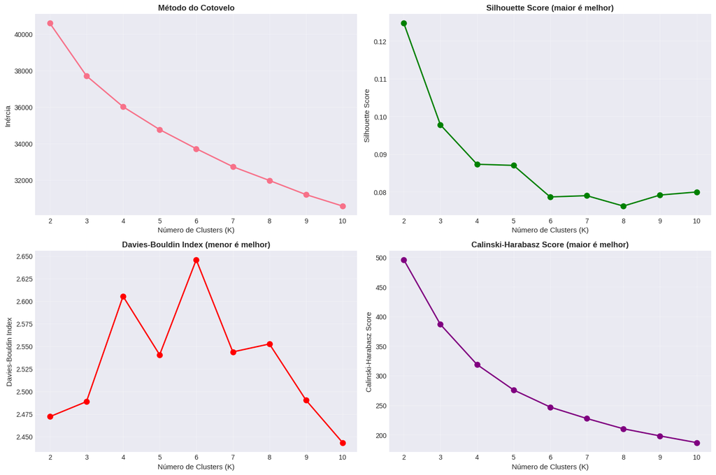

```python
fig, axes = plt.subplots(2, 2, figsize=(15, 10))

# Inércia
axes[0, 0].plot(metricas_k['K'], metricas_k['Inércia'], 'o-', linewidth=2, markersize=8)
axes[0, 0].set_xlabel('Número de Clusters (K)', fontsize=11)
axes[0, 0].set_ylabel('Inércia', fontsize=11)
axes[0, 0].set_title('Método do Cotovelo', fontsize=12, fontweight='bold')
axes[0, 0].grid(True, alpha=0.3)

# Silhouette
axes[0, 1].plot(metricas_k['K'], metricas_k['Silhouette'], 'o-', color='green', linewidth=2, markersize=8)
axes[0, 1].set_xlabel('Número de Clusters (K)', fontsize=11)
axes[0, 1].set_ylabel('Silhouette Score', fontsize=11)
axes[0, 1].set_title('Silhouette Score (maior é melhor)', fontsize=12, fontweight='bold')
axes[0, 1].grid(True, alpha=0.3)

# Davies-Bouldin
axes[1, 0].plot(metricas_k['K'], metricas_k['Davies-Bouldin'], 'o-', color='red', linewidth=2, markersize=8)
axes[1, 0].set_xlabel('Número de Clusters (K)', fontsize=11)
axes[1, 0].set_ylabel('Davies-Bouldin Index', fontsize=11)
axes[1, 0].set_title('Davies-Bouldin Index (menor é melhor)', fontsize=12, fontweight='bold')
axes[1, 0].grid(True, alpha=0.3)

# Calinski-Harabasz
axes[1, 1].plot(metricas_k['K'], metricas_k['Calinski-Harabasz'], 'o-', color='purple', linewidth=2, markersize=8)
axes[1, 1].set_xlabel('Número de Clusters (K)', fontsize=11)
axes[1, 1].set_ylabel('Calinski-Harabasz Score', fontsize=11)
axes[1, 1].set_title('Calinski-Harabasz Score (maior é melhor)', fontsize=12, fontweight='bold')
axes[1, 1].grid(True, alpha=0.3)

plt.tight_layout()
plt.show()
```

### Propósito da Análise

**Aplicar K-means com K ótimo** identificado para segmentar os profissionais em clusters bem definidos.

```python
k_final = int(k_otimo)

print(f"Aplicando K-means com K = {k_final}...")
print("="*80)

kmeans_final = KMeans(
    n_clusters=k_final,
    init='k-means++',
    n_init=100,
    max_iter=500,
    random_state=42
)

clusters = kmeans_final.fit_predict(df_final)

print("K-means aplicado com sucesso!")

# Adicionar clusters aos datasets
df_final['Cluster'] = clusters
df_cluster_clean['Cluster'] = clusters

# Distribuição dos clusters
print("\n DISTRIBUIÇÃO DOS CLUSTERS:")
print("="*80)
cluster_counts = pd.DataFrame({
    'Cluster': range(k_final),
    'N': [sum(clusters == i) for i in range(k_final)],
    '%': [(sum(clusters == i) / len(clusters) * 100) for i in range(k_final)]
})
cluster_counts['%'] = cluster_counts['%'].round(2)
cluster_counts
```

```
Aplicando K-means com K = 2...
================================================================================
K-means aplicado com sucesso!

 DISTRIBUIÇÃO DOS CLUSTERS:
================================================================================
```

|  | Cluster | N | % |
| --- | --- | --- | --- |
| 0 | 0 | 1469 | 46.870 |
| 1 | 1 | 1665 | 53.130 |

### Propósito da Análise

**Examinar centroides dos clusters** (médias das variáveis padronizadas) para entender características centrais de cada grupo.

```python
# Centroides
centroides = pd.DataFrame(
    kmeans_final.cluster_centers_,
    columns=df_final.drop('Cluster', axis=1).columns
)
centroides.index = [f'Cluster {i}' for i in range(k_final)]

print("CENTROIDES (Z-scores):")
print("="*80)
print("Valores positivos indicam acima da média, negativos abaixo da média")
centroides.T.round(3)
```

```
CENTROIDES (Z-scores):
================================================================================
Valores positivos indicam acima da média, negativos abaixo da média
```

|  | Cluster 0 | Cluster 1 |
| --- | --- | --- |
| 1.a_idade | -0.470 | 0.414 |
| 1.b_genero | -0.047 | 0.042 |
| 1.i.2_regiao_onde_mora | -0.094 | 0.083 |
| 1.l_nivel_de_ensino | -0.343 | 0.303 |
| 2.f_cargo_atual | -0.317 | 0.280 |
| 2.g_nivel | -0.800 | 0.706 |
| 2.h_faixa_salarial | -0.750 | 0.662 |
| 2.i_tempo_de_experiencia_em_dados | -0.669 | 0.590 |
| 2.c_numero_de_funcionarios | 0.256 | -0.226 |
| 2.b_setor | 0.019 | -0.017 |
| 4.a.1_atuacao_em_dados | -0.319 | 0.282 |
| 4.e_linguagem_mais_usada | 0.086 | -0.076 |
| 4.i_cloud_preferida | 0.088 | -0.078 |
| 2.k_satisfeito_atualmente | -0.143 | 0.126 |
| 2.r_modelo_de_trabalho_atual | -0.134 | 0.118 |

## 9. Validação e Interpretação

### Propósito da Análise

**Validar clusters através de ANOVA** para identificar quais variáveis melhor discriminam os grupos, confirmando diferenças estatisticamente significativas.

```python
print("="*80)
print(" "*30 + "VALIDAÇÃO (ANOVA)")
print("="*80)

anova_results = []

for col in df_final.drop('Cluster', axis=1).columns:
    groups = [df_final[df_final['Cluster'] == i][col] for i in range(k_final)]
    f_stat, p_value = stats.f_oneway(*groups)

    anova_results.append({
        'Variável': col,
        'F-statistic': f_stat,
        'p-value': p_value,
        'Significativo': 'Sim ✓' if p_value < 0.001 else 'Não'
    })

anova_df = pd.DataFrame(anova_results).sort_values('F-statistic', ascending=False)

print("\n TOP 10 VARIÁVEIS MAIS DISCRIMINANTES:")
print("="*80)
print(anova_df.head(10))

print(f"\n Total de variáveis significativas (p < 0.001): {sum(anova_df['Significativo'] == 'Sim ✓')}")
```

```
================================================================================
                              VALIDAÇÃO (ANOVA)
================================================================================

 TOP 10 VARIÁVEIS MAIS DISCRIMINANTES:
================================================================================
                             Variável  F-statistic  p-value Significativo
5                           2.g_nivel     4069.704    0.000         Sim ✓
6                  2.h_faixa_salarial     3088.538    0.000         Sim ✓
7   2.i_tempo_de_experiencia_em_dados     2043.524    0.000         Sim ✓
0                           1.a_idade      757.286    0.000         Sim ✓
3                 1.l_nivel_de_ensino      362.786    0.000         Sim ✓
10             4.a.1_atuacao_em_dados      309.921    0.000         Sim ✓
4                     2.f_cargo_atual      305.555    0.000         Sim ✓
8          2.c_numero_de_funcionarios      192.666    0.000         Sim ✓
13          2.k_satisfeito_atualmente       57.725    0.000         Sim ✓
14       2.r_modelo_de_trabalho_atual       50.300    0.000         Sim ✓

 Total de variáveis significativas (p < 0.001): 13
```

### Propósito da Análise

**Visualizar clusters em 2D usando PCA** para avaliar separação visual dos grupos e validar qualidade da segmentação.

```
Aplicando PCA para visualização...
================================================================================
PCA aplicado!

 Variância explicada: 32.22%
   • PC1: 20.33%
   • PC2: 11.89%
```

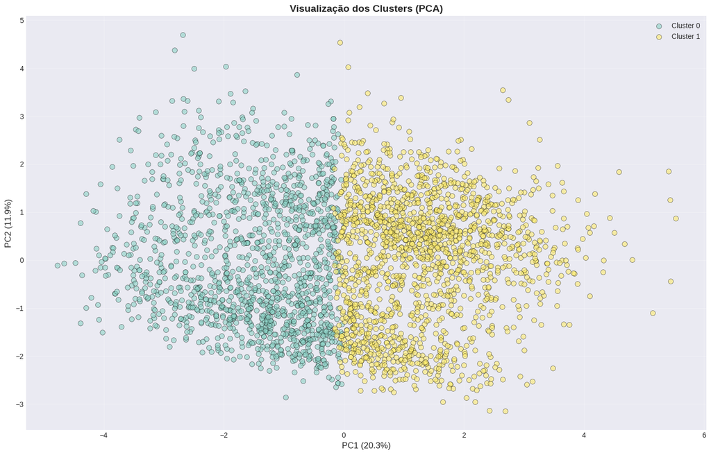

```python
print("Aplicando PCA para visualização...")
print("="*80)

pca = PCA(n_components=2, random_state=42)
df_pca = pca.fit_transform(df_final.drop('Cluster', axis=1))

print(f"PCA aplicado!")
print(f"\n Variância explicada: {sum(pca.explained_variance_ratio_)*100:.2f}%")
print(f"   • PC1: {pca.explained_variance_ratio_[0]*100:.2f}%")
print(f"   • PC2: {pca.explained_variance_ratio_[1]*100:.2f}%")

# Criar visualização
plt.figure(figsize=(14, 9))
colors = plt.cm.Set3(np.linspace(0, 1, k_final))

for i in range(k_final):
    mask = df_final['Cluster'] == i
    plt.scatter(df_pca[mask, 0], df_pca[mask, 1],
               c=[colors[i]], label=f'Cluster {i}',
               alpha=0.6, s=50, edgecolors='black', linewidth=0.5)

plt.xlabel(f'PC1 ({pca.explained_variance_ratio_[0]*100:.1f}%)', fontsize=12)
plt.ylabel(f'PC2 ({pca.explained_variance_ratio_[1]*100:.1f}%)', fontsize=12)
plt.title('Visualização dos Clusters (PCA)', fontsize=14, fontweight='bold')
plt.legend(fontsize=10)
plt.grid(True, alpha=0.3)
plt.tight_layout()
plt.show()
```

## 10. Perfil dos Clusters

### Propósito da Análise

**Caracterizar cada cluster** detalhadamente através de estatísticas descritivas e modas das variáveis originais para criar perfis profissionais interpretáveis.

```python
print("="*80)
print(" "*25 + "PERFIL DOS CLUSTERS")
print("="*80)

def gerar_resumo_cluster(df, cluster_id):
    """Gera resumo das características de um cluster"""
    df_c = df[df['Cluster'] == cluster_id]
    n = len(df_c)

    resumo = f"\n{'='*80}\n"
    resumo += f"CLUSTER {cluster_id} - {n} profissionais ({n/len(df)*100:.1f}%)\n"
    resumo += f"{'='*80}\n"

    # Demográfico
    if '1.a_idade' in df_c.columns:
        resumo += f"\n DEMOGRÁFICO:\n"
        resumo += f"  • Idade média: {df_c['1.a_idade'].mean():.1f} anos\n"

    if '1.b_genero' in df_c.columns:
        genero_top = df_c['1.b_genero'].mode()[0] if len(df_c['1.b_genero'].mode()) > 0 else 'N/A'
        resumo += f"  • Gênero predominante: {genero_top}\n"

    if '1.i.2_regiao_onde_mora' in df_c.columns:
        regiao_top = df_c['1.i.2_regiao_onde_mora'].mode()[0] if len(df_c['1.i.2_regiao_onde_mora'].mode()) > 0 else 'N/A'
        resumo += f"  • Região predominante: {regiao_top}\n"

    if '1.l_nivel_de_ensino' in df_c.columns:
        ensino_top = df_c['1.l_nivel_de_ensino'].mode()[0] if len(df_c['1.l_nivel_de_ensino'].mode()) > 0 else 'N/A'
        resumo += f"  • Nível de ensino: {ensino_top}\n"

    # Profissional
    resumo += f"\n PROFISSIONAL:\n"

    if '2.g_nivel' in df_c.columns:
        nivel_top = df_c['2.g_nivel'].mode()[0] if len(df_c['2.g_nivel'].mode()) > 0 else 'N/A'
        resumo += f"  • Senioridade: {nivel_top}\n"

    if '2.f_cargo_atual' in df_c.columns:
        cargo_top = df_c['2.f_cargo_atual'].mode()[0] if len(df_c['2.f_cargo_atual'].mode()) > 0 else 'N/A'
        resumo += f"  • Cargo: {cargo_top}\n"

    if '2.h_faixa_salarial' in df_c.columns:
        salario_top = df_c['2.h_faixa_salarial'].mode()[0] if len(df_c['2.h_faixa_salarial'].mode()) > 0 else 'N/A'
        resumo += f"  • Faixa salarial: {salario_top}\n"

    if '2.i_tempo_de_experiencia_em_dados' in df_c.columns:
        exp_top = df_c['2.i_tempo_de_experiencia_em_dados'].mode()[0] if len(df_c['2.i_tempo_de_experiencia_em_dados'].mode()) > 0 else 'N/A'
        resumo += f"  • Experiência: {exp_top}\n"

    if '2.b_setor' in df_c.columns:
        setor_top = df_c['2.b_setor'].mode()[0] if len(df_c['2.b_setor'].mode()) > 0 else 'N/A'
        resumo += f"  • Setor: {setor_top}\n"

    # Técnico
    resumo += f"\n TÉCNICO:\n"

    if '4.a.1_atuacao_em_dados' in df_c.columns:
        atuacao_top = df_c['4.a.1_atuacao_em_dados'].mode()[0] if len(df_c['4.a.1_atuacao_em_dados'].mode()) > 0 else 'N/A'
        resumo += f"  • Atuação: {atuacao_top}\n"

    if '4.e_linguagem_mais_usada' in df_c.columns:
        lang_top = df_c['4.e_linguagem_mais_usada'].mode()[0] if len(df_c['4.e_linguagem_mais_usada'].mode()) > 0 else 'N/A'
        resumo += f"  • Linguagem: {lang_top}\n"

    if '4.i_cloud_preferida' in df_c.columns:
        cloud_top = df_c['4.i_cloud_preferida'].mode()[0] if len(df_c['4.i_cloud_preferida'].mode()) > 0 else 'N/A'
        resumo += f"  • Cloud: {cloud_top}\n"

    if '4.k_ferramenta_de_bi_preferida' in df_c.columns:
        bi_top = df_c['4.k_ferramenta_de_bi_preferida'].mode()[0] if len(df_c['4.k_ferramenta_de_bi_preferida'].mode()) > 0 else 'N/A'
        resumo += f"  • Ferramenta BI: {bi_top}\n"

    # Satisfação
    resumo += f"\n SATISFAÇÃO E MODELO DE TRABALHO:\n"

    if '2.k_satisfeito_atualmente' in df_c.columns:
        satisfeitos = df_c['2.k_satisfeito_atualmente'].astype(str).str.upper() == 'TRUE'
        pct_satisfeito = satisfeitos.sum() / len(df_c) * 100
        resumo += f"  • Satisfeitos: {pct_satisfeito:.1f}%\n"

    if '2.r_modelo_de_trabalho_atual' in df_c.columns:
        modelo_top = df_c['2.r_modelo_de_trabalho_atual'].mode()[0] if len(df_c['2.r_modelo_de_trabalho_atual'].mode()) > 0 else 'N/A'
        resumo += f"  • Modelo de trabalho: {modelo_top}\n"

    return resumo

# Gerar resumos
print("\n" + "#"*80)
print("#" + " "*28 + "RESUMO DOS CLUSTERS" + " "*31 + "#")
print("#"*80)

for cluster_id in sorted(df_cluster_clean['Cluster'].unique()):
    print(gerar_resumo_cluster(df_cluster_clean, cluster_id))
```

```
================================================================================
                         PERFIL DOS CLUSTERS
================================================================================

################################################################################
#                            RESUMO DOS CLUSTERS                               #
################################################################################

================================================================================
CLUSTER 0 - 1469 profissionais (46.9%)
================================================================================

 DEMOGRÁFICO:
  • Idade média: 27.8 anos
  • Gênero predominante: Masculino
  • Região predominante: Sudeste
  • Nível de ensino: Graduação/Bacharelado

 PROFISSIONAL:
  • Senioridade: Pleno
  • Cargo: Analista de Dados/Data Analyst
  • Faixa salarial: de R$ 4.001/mês a R$ 6.000/mês
  • Experiência: de 1 a 2 anos
  • Setor: Finanças ou Bancos

 TÉCNICO:
  • Atuação: Análise de Dados
  • Linguagem: SQL
  • Cloud: Não sei opinar / Não tenho preferência

 SATISFAÇÃO E MODELO DE TRABALHO:
  • Satisfeitos: 63.2%
  • Modelo de trabalho: Modelo 100% remoto


================================================================================
CLUSTER 1 - 1665 profissionais (53.1%)
================================================================================

 DEMOGRÁFICO:
  • Idade média: 33.6 anos
  • Gênero predominante: Masculino
  • Região predominante: Sudeste
  • Nível de ensino: Pós-graduação

 PROFISSIONAL:
  • Senioridade: Sênior
  • Cargo: Cientista de Dados/Data Scientist
  • Faixa salarial: de R$ 8.001/mês a R$ 12.000/mês
  • Experiência: de 3 a 4 anos
  • Setor: Finanças ou Bancos

 TÉCNICO:
  • Atuação: Engenharia de Dados
  • Linguagem: SQL
  • Cloud: Amazon Web Services (AWS)

 SATISFAÇÃO E MODELO DE TRABALHO:
  • Satisfeitos: 75.6%
  • Modelo de trabalho: Modelo 100% remoto
```

## 11. Conclusões e Discussão

### Principais Achados

#### 1.3 Satisfação Profissional

Os clusters apresentam **níveis variados de satisfação**, sugerindo que:

- Satisfação não está uniformemente distribuída
- Pode estar associada a fatores como senioridade, salário e modelo de trabalho
- Existe espaço para melhorias em determinados perfis profissionais

### Implicações Práticas

#### 2.1 Para Profissionais

**Benchmarking e Desenvolvimento de Carreira:**

- Identificar em qual cluster seu perfil se encaixa
- Comparar salário, experiência e tecnologias com pares
- Planejar transições entre clusters (upskilling, reskilling)
- Entender trajetórias típicas de evolução profissional

**Exemplo prático:** Um profissional júnior pode identificar o cluster de seniores com maior satisfação e mapear as competências necessárias para alcançá-lo.

#### 2.2 Para Empresas

**Gestão de Talentos e Estruturação de Times:**

- Construir times complementares com perfis de diferentes clusters
- Definir planos de carreira baseados em clusters reais do mercado
- Ajustar remuneração de acordo com benchmarks por cluster
- Desenvolver estratégias de retenção específicas para cada perfil

**Exemplo prático:** Empresas podem identificar clusters com maior taxa de rotatividade e desenvolver programas de retenção direcionados.

#### 2.3 Para Instituições de Ensino

**Alinhamento Curricular e Capacitação:**

- Desenvolver trilhas de formação alinhadas aos clusters identificados
- Priorizar tecnologias e competências mais demandadas
- Criar especializações para perfis específicos
- Ajustar currículos à realidade do mercado brasileiro

#### 2.4 Para Formuladores de Políticas

**Compreensão do Ecossistema:**

- Mapear lacunas de formação e capacitação
- Identificar regiões com déficit de profissionais qualificados
- Desenvolver políticas de incentivo à diversidade no setor
- Apoiar transições de carreira para área de dados

### Limitações do Estudo

#### 3.1 Amostragem e Representatividade

**Viés de Seleção:**

- Amostra não probabilística (pesquisa voluntária)
- Possível sobre-representação de profissionais ativos em comunidades de dados
- Sub-representação de profissionais menos engajados ou em empresas tradicionais

**Implicação:** Os clusters podem não capturar perfis "silenciosos" do mercado.

#### 3.2 Temporalidade

**Snapshot de 2024:**

- Mercado de dados é altamente dinâmico
- Novas tecnologias e papéis emergem rapidamente
- Clusters podem mudar em 6-12 meses

**Implicação:** Resultados devem ser interpretados como fotografia de um momento específico.

#### 3.3 Simplificação da Realidade

**Redução de Complexidade:**

- Profissionais são multifacetados e não se encaixam perfeitamente em clusters
- Análise quantitativa não captura nuances qualitativas
- Transições entre clusters são fluidas, não discretas

**Implicação:** Clusters são arquétipos úteis, mas não rótulos definitivos.

#### 3.4 Variáveis Disponíveis

**Limitação de Dados:**

- Análise restrita às variáveis coletadas na pesquisa
- Aspectos importantes podem não ter sido capturados (soft skills, cultura organizacional, etc.)
- Mapeamentos ordinais são aproximações

**Implicação:** Clusters refletem as dimensões mensuradas, não a totalidade da realidade profissional.

## Conclusão Final

#### Além das Competências Técnicas

O sucesso na área depende não apenas de competências técnicas (linguagens, ferramentas, metodologias), mas de **compreender o ecossistema** e **posicionar-se estrategicamente** em um mercado dinâmico e competitivo. Profissionais que entendem sua posição relativa e as possibilidades de evolução tendem a fazer escolhas mais informadas.

#### Segmentação Como Ferramenta Estratégica

Para empresas, a segmentação permite **gestão personalizada de talentos**, reconhecendo que diferentes perfis têm necessidades, motivações e trajetórias distintas. Uma abordagem única ("one size fits all") tende a ser ineficaz em mercado tão heterogêneo.

#### Educação Baseada em Evidências

Para instituições de ensino, os clusters fornecem **arquétipos reais** que podem orientar o desenvolvimento curricular, evitando formações genéricas desconectadas das demandas efetivas do mercado.

#### A Análise Como Ponto de Partida

Por fim, esta análise não deve ser vista como um **fim em si mesma**, mas como **ponto de partida** para investigações mais profundas, discussões estratégicas e ações concretas de desenvolvimento do ecossistema de dados brasileiro.

> *"Dados transformam organizações. Profissionais de dados transformam dados. Mas são as análises como esta que nos permitem compreender e transformar a própria profissão de dados."*